# stackr missing data visualization analysis

Thierry Gosselin

2016-10-27

# Objectives

Learn how to visualize missing genotypes in your genomic dataset with the function `stackr::missing_visualization` (time = 15 min).

# Workflow

The function `missing_visualization` in stackr uses various genomic input files and conduct identity-by-missingness analyses (IBM) using Principal Coordinates Analysis (PCoA), also called Multidimensional Scaling (MDS). Figures and summary tables of missing information at the marker, individual and population level are generated. Below, the simplest form of the function to get results … fast! More options are available, see function documentation.

## Prepare your R workspace

1. Clean your desk and load the required libraries (copy/paste in one block):

```r
rm(list = ls())
if (!require("pacman")) install.packages("pacman")
library("pacman")
pacman::p_load(devtools, reshape2, ggplot2, stringr, stringi, plyr, dplyr, tidyr, readr, purrr, data.table, ape, adegenet, parallel, lazyeval, randomForestSRC)
# repeat to load libraries that were just installed
pacman::p_load(devtools, reshape2, ggplot2, stringr, stringi, plyr, dplyr, tidyr, readr, purrr, data.table, ape, adegenet, parallel, lazyeval, randomForestSRC)
if (!require("stackr")) {
  #devtools::install_github("thierrygosselin/stackr", build_vignettes = TRUE)
  library("stackr")
}
```

2. Set your working directory

```r
setwd("~/Documents")
```

## Get the data and create a strata file

3. Dataset: in this example, we use the data in Ferchaud and Hansen (2015 and 2016) paper.

```r
writeBin(httr::content(httr::GET("http://datadryad.org/bitstream/handle/10255/dryad.97237/sticklebacks_Danish.vcf?sequence=1"), "raw"), "example_vcf2dadi_ferchaud_2015.vcf")
```

4. We need to generate a strata file necessary to make the vcf population-wise. The strata file is a tab-delimited file or object, in the global environment, with a minimum of 2 columns: `INDIVIDUALS` and `STRATA`. The `STRATA` and remaining columns can be any hierarchical grouping.
- Because the population id is contained in the name of the individuals and easily extracted with string command, we use the function `stackr::individuals2strata`.

```r
# here is one individual id:
Hadsten10_q_75.align
# with pop starting at position 1 and to keep only 3 characters (necessary to discriminate populations from each other)     we stop at... 3
```

- For info on the function use: `?individuals2strata`. Don’t have this kind of names… you can also make the strata file by hand, the old fashion way.
- For your data, you might not need to make a strata file if you have already run on your data, the strata file is similar to a stacks `population map file`, make sure you have the required column names (`INDIVIDUALS` and `STRATA`).
- We will extract the id from the first line of the vcf file. If the individuals were in a single column in a file (e.g. “individuals.txt”), make sure the column is named `INDIVIDUALS` and use the file directly in the function `stackr::individuals2strata`.
- We could put all the lines below in one call, but for clarity we’ll break down the steps:

```r
# Isolate the first line
id.vcf <- data.table::fread(
  input = "example_vcf2dadi_ferchaud_2015.vcf",
  sep = "\t",
  stringsAsFactors = FALSE,
  header = TRUE,
  drop = c("POS", "ID", "REF", "ALT", "QUAL", "FILTER", "INFO", "FORMAT"),
  skip = "CHROM",
  nrows = 1,
  showProgress = TRUE,
  verbose = FALSE
) %>%
  as_data_frame() %>%
  select(-`#CHROM`)
  # to keep only the column name
  individuals <- data.frame(INDIVIDUALS = colnames(id.vcf))
```

```r
# create the strata
strata.stickleback <- stackr::individuals2strata(
data = individuals,
strata.start = 1,
strata.end = 3,
filename = "strata.stickleback.tsv"
)
```

## Run the function stackr::missing_visualization

```r
ibm <- stackr::missing_visualization(
data = "example_vcf2dadi_ferchaud_2015.vcf", # VCF file, but see function documentation for other options
strata = "strata.stickleback.tsv") # the strata file just created
```

```
#######################################################################
################### stackr: missing_visualization #####################
#######################################################################
```

```
Using input file in your directory
Importing the VCF...
Making the VCF population wise
```

This is the simplest way to run the function. And the output in RStudio console should be similar to what you see below:

```r
#######################################################################
################### stackr: missing_visualization #####################
#######################################################################
Using input file in your directory
File type: VCF
Whitelist of markers: no
Blacklisted individuals: no
strata file: yes
Importing the VCF...
Making the VCF population wise
Tidying the vcf...
Erasing genotype: no
Removing monomorphic markers: yes
Scanning for monomorphic markers...
Number of monomorphic markers removed: 0
Including the strata file
Principal Coordinate Analysis (PCoA)...
Generating Identity by missingness plot
Generating missing information summary tables and plot
Missingness per individuals
Missingness per populations
Missingness per markers
```

A new object `ibm` was created in your global environment. It’s a list and to view it’s content use `names(ibm)`

```r
"ibm.plot.pco1.pco2.strata.POP_ID"
"ibm.plot.pco1.pco3.strata.POP_ID"
"ibm.plot.pco2.pco3.strata.POP_ID"
"ibm.plot.pco3.pco4.strata.POP_ID"
"blacklist.id.missing.10"
"blacklist.id.missing.20"
"blacklist.id.missing.30"
"blacklist.id.missing.40"
"blacklist.id.missing.50"
"blacklist.id.missing.60"
"blacklist.id.missing.70"
"tidy.data"
"tidy.data.binary"
"vectors"
"heatmap"
"missing.genotypes.ind"
"missing.genotypes.ind.plot"
"missing.genotypes.pop"
"missing.genotypes.pop.plot"
"missing.genotypes.markers"
"missing.genotypes.markers.plot"
```

The function generates by default the IBM-PCoA plot, the heatmap plot and several plots showing the distribution of missing genotypes by individuals, pop and markers. Blacklists of individuals are included in the list `ibm` and written to the working directory (defaults from 10% to 70%, that automatically stops if no individuals at the threshold is found, can be changed with `ind.missing.geno.threshold` argument). Tables with summary missing information along the vectors of eigenvalues of the principal coordinates analysis are also part of the list output. All these objects are accessed with `$`.

For the second run, we are going to select all the groupings in the strata file. This will allow us to get the IBM-PCoA plot for each groupings automatically.

```r
ibm <- stackr::missing_visualization(
data = "example_vcf2dadi_ferchaud_2015.vcf", # VCF file, but see function documentation for other options
# blacklist.id = "blacklist.id.missing.10.tsv",
strata = "strata.stickleback.tsv", # 4 columns: INDIVIDUALS, STRATA, POP_TYPE, ECOTYPE
strata.select = c("POP_ID", "POP_TYPE", "ECOTYPE") # STRATA is changed to POP_ID automatically
)
```

```
#######################################################################
################### stackr: missing_visualization #####################
#######################################################################
```

```
Using input file in your directory
Importing the VCF...
Making the VCF population wise
Tidying the vcf...
Erasing genotype: no
Including the strata file
Principal Coordinate Analysis (PCoA)...
Generating Identity by missingness plot
Generating missing information summary tables and plot
Missingness per individuals
Missingness per populations
Missingness per markers
```

## Visualization

1. To view the IBM-PCoA plot made with POP_ID grouping:

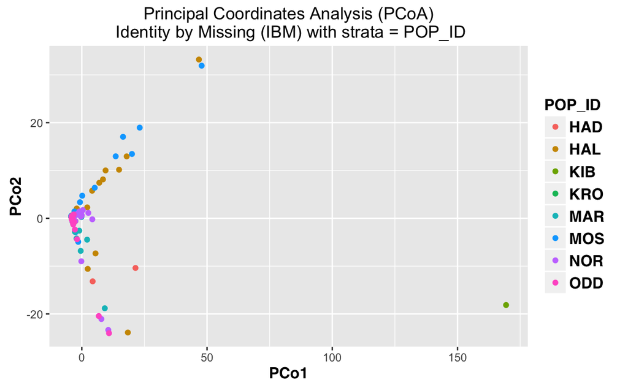

2. To view 2 different axis of the IBM-PCoA plot made with POP_ID grouping:

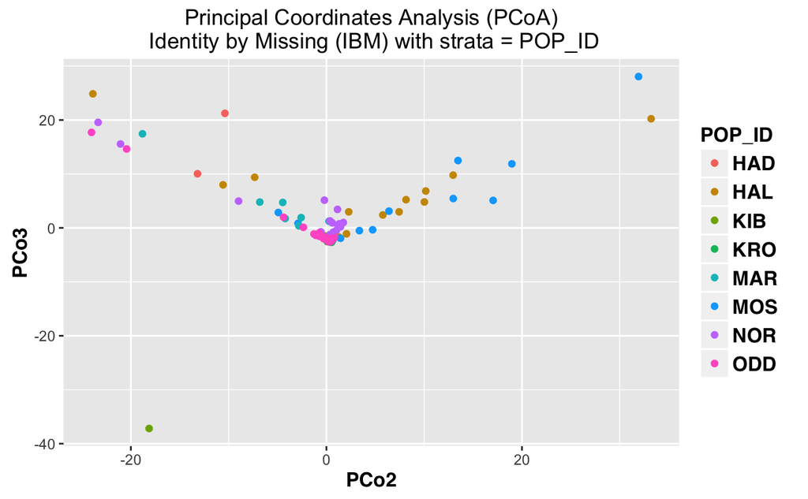

3. To view the IBM-PCoA plot made with ECOTYPE grouping:

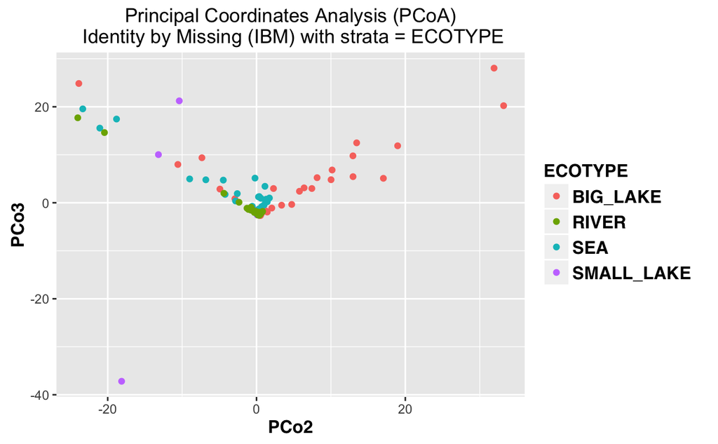

4. Create a new object, outside the list, for the heatmap figure:

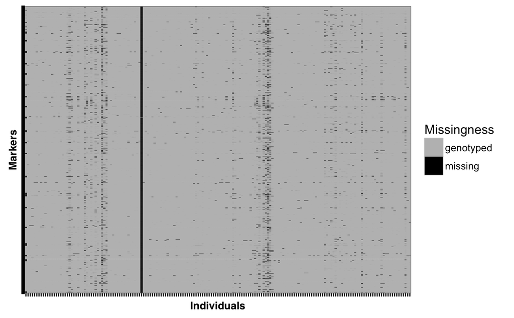

5. To save the heatmap plots, code below, though you migh want to take a long coffee break, have lunch or even best, do it overnight while it runs…

```r
# vectorial pdf:
ggsave(filename = "stickleback.missing.heatmap.pdf", width = 10, height = 20, dpi = 300, units = "cm", useDingbats = F)
# png:
ggsave(filename = "stickleback.missing.heatmap.png", width = 10, height = 20, dpi = 100, units = "cm")
```

6. View the table with summary of missing genotypes per individuals:

| INDIVIDUALS | POP_ID | MISSING_GENOTYPE | MARKER_NUMBER | PERC |
| --- | --- | --- | --- | --- |
| Hadsten1-q-75.align | HAD | 3887 | 31802 | 12.22 |
| Hadsten10-q-75.align | HAD | 125 | 31802 | 0.39 |
| Hadsten11-q-75.align | HAD | 55 | 31802 | 0.17 |
| Hadsten12-q-75.align | HAD | 90 | 31802 | 0.28 |
| Hadsten13-q-75.align | HAD | 77 | 31802 | 0.24 |
| Hadsten14-q-75.align | HAD | 287 | 31802 | 0.90 |
| Hadsten15-q-75.align | HAD | 123 | 31802 | 0.39 |
| Hadsten16-q-75.align | HAD | 141 | 31802 | 0.44 |
| Hadsten17-q-75.align | HAD | 106 | 31802 | 0.33 |
| Hadsten18-q-75.align | HAD | 187 | 31802 | 0.59 |

[output cut: 167 more lines]

7. To view the distribution of missing genotypes per individuals

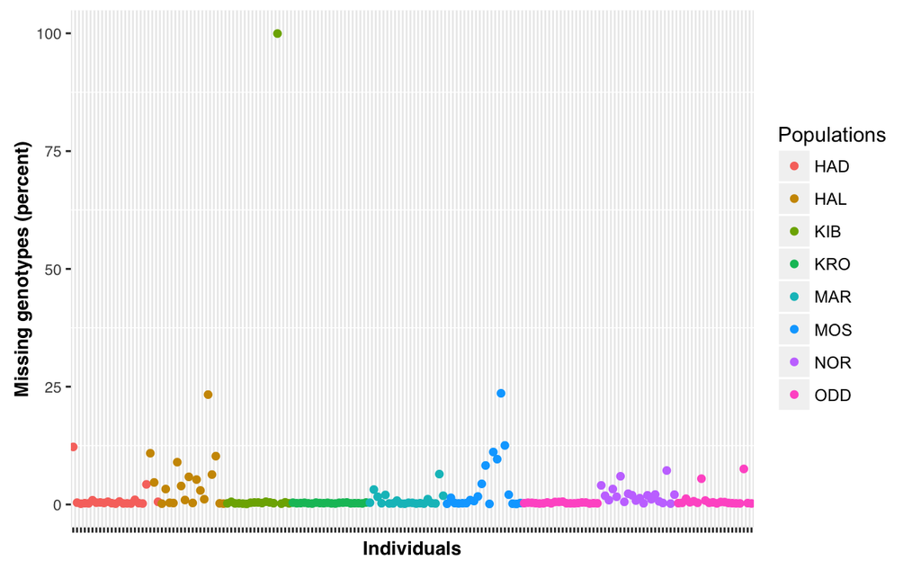

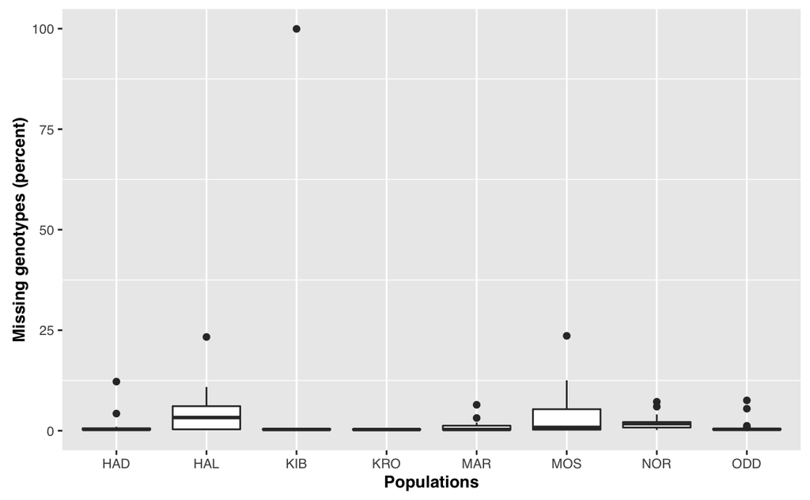

9. Explore the rest by yourself!

### Interpretation

Do you see patterns in your plots that provides insight about the relationships that missing values might have with other variables (inspired from [r4ds](http://r4ds.had.co.nz/exploratory-data-analysis-eda.html)).

If you see a pattern, ask yourself:

- Is the pattern due to coincidence (i.e. random chance)?
- Could you describe the relationship in the pattern ?
- How strong is the relationship implied by the pattern?
- What other variables might affect the relationship?
- Does the relationship change if you look at individual subgroups of the data?
- Do you think the pattern observed in the data could impact the clustering analysis?

### Arguments

- use `strata.select` to select columns from the strata file to generate PCoA-IBM plots. If you have several columns to test e.g. library, sequencer, sequencing lanes, sampling sites, populations, use inside a string to get all of them!
- use `distance.method` to explore other distance metric used by the function `dist`

### Filtering strategies

- explore the impact of different filtering parameters on missing genotypes pattern, with available arguments: e.g. `snp.ld`, `common.markers`, `maf.thresholds` arguments to quickly generate the figures.
- test your own whitelist of markers with `whitelist.markers`
- use the blacklist of individuals created with the function to **manage** missing data inside filtering pipelines
- excluding/including individuals, populations and markers to test the impact of filtering on polymorphism discovery
- ready to test missing data imputations ? Most stackr functions have built-in imputations arguments.

## References

Ferchaud A, Hansen MM (2016) The impact of selection, gene flow and demographic history on heterogeneous genomic divergence: threespine sticklebacks in divergent environments. Molecular Ecology 25(1): 238–259. http://dx.doi.org/10.1111/mec.13399

Ferchaud A, Hansen MM (2015) Data from: The impact of selection, gene flow and demographic history on heterogeneous genomic divergence: threespine sticklebacks in divergent environments. Dryad Digital Repository. http://dx.doi.org/10.5061/dryad.kp11q

Danecek P, Auton A, Abecasis G et al. (2011) The variant call format and VCFtools. Bioinformatics, 27, 2156–2158.

Purcell S, Neale B, Todd-Brown K et al. (2007) PLINK: a tool set for whole-genome association and population-based linkage analyses. American Journal of Human Genetics, 81, 559–575.